# Corey Austen Assignment 1

# Problem 1:

## a)

Create a time plot for the time series of spot prices. Make sure the plot is correctly labeled and titled. Analyze the time trend displayed by the plot, and discuss if data show any striking pattern, such as upward/downward trends or seasonality?

## Answer:

The spot price as shown in the time series plot does appear to show trend, seasonality, and may be cyclical. You can see the trend year over year from 2004 to 2008, then there is a sharp decline in the middle of 2008. The prices then appear to trend upward again, from mid-2009 to mid-2014, then there is a sharp decline again. You can also see the seasonality of the price as well, with the prices dropping just before summer, rising through the summer, then falling again as the year ends. I would also argue that there is a cycle to the prices as well, as we see the crash in the price in mid-2008 and again in mid-2014. Perhaps the most striking thing in the graph is the price shaply declining in 2008 as a result of the resession.

```r
library(tseries)
library(zoo)
library(ggplot2)
library(ggfortify)
#import crude oil dataset into a dataframe
work_dir <- "C:/Users/Corey/Documents/GitHub/time_series/Week 1/Data"
setwd(work_dir)
```

[output not shown]

```r
crude = read.table('crudeoil_w0416.csv', header=T, sep=',')
# create time series for oil prices
```

```r
#examining the newly created dataframe
str(crude)
```

```
'data.frame':   627 obs. of  2 variables:
 $ date : Factor w/ 627 levels "1-Apr-05","1-Apr-11",..: 232 612 149 315 477 550 87 253 397 536 ...
 $ price: num  32.7 33.9 34.5 35.5 33.6 ...
```

```r
class(crude)
```

```
[1] "data.frame"
```

```r
summary(crude)
```

```
       date         price
 1-Apr-05:  1   Min.   : 32.68
 1-Apr-11:  1   1st Qu.: 57.85
 1-Aug-08:  1   Median : 74.98
 1-Aug-14:  1   Mean   : 75.45
 1-Dec-06:  1   3rd Qu.: 94.61
 1-Feb-08:  1   Max.   :142.52
 (Other) :621
```

```r
#Creating a TS object with the crude data
crudets = zoo(crude$price, as.Date(as.character(crude$date), format = "%e-%b-%y"))
#Taking a look at the newly created object
head(time(crudets))
```

```
[1] "2004-01-02" "2004-01-09" "2004-01-16" "2004-01-23" "2004-01-30" "2004-02-06"
```

```r
start(crudets)
```

```
[1] "2004-01-02"
```

```r
end(crudets)
```

```
[1] "2016-01-01"
```

```r
# sort data in chronological order
# set variable Date as time/date variable
crude$date=as.Date(as.character(crude$date), format = "%e-%b-%y")
crude=crude[order(crude$date),]
```

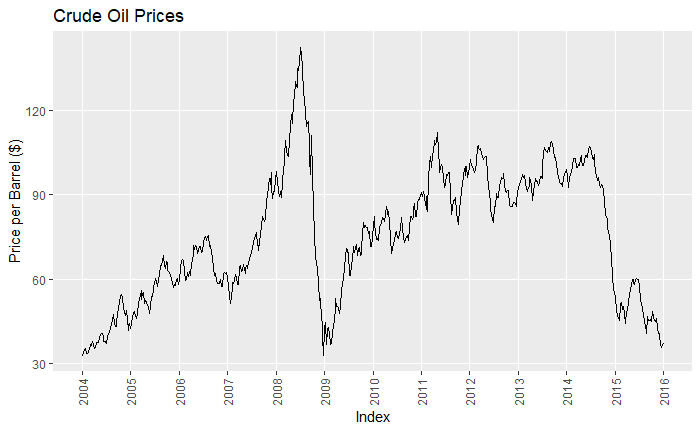

```r
autoplot(crudets) + labs(title="Crude Oil Prices", y="Price per Barrel ($)") + scale_x_date(date_breaks = "1 year", date_minor_breaks = "1 year", date_labels = "%Y") + theme(axis.text.x = element_text(angle = 90, vjust=0.5), panel.grid.minor = element_blank())
```

## b)

Compute the percentage change rate of spot prices using the formula rate = (pt - pt-1) /pt-1, where pt is the oil price . Plot the percent change. Describe what you see.

## Answer:

```r
#Calculating the rate of change in spot price
pricelag = lag(crudets,k=-1);
rate =((crudets-pricelag)/pricelag)*100
summary(rate)
```

```
     Index                 rate
 Min.   :2004-01-09   Min.   :-17.3864
 1st Qu.:2007-01-06   1st Qu.: -2.2138
 Median :2010-01-04   Median :  0.1755
 Mean   :2010-01-04   Mean   :  0.1071
 3rd Qu.:2013-01-02   3rd Qu.:  2.5653
 Max.   :2016-01-01   Max.   : 28.5628
```

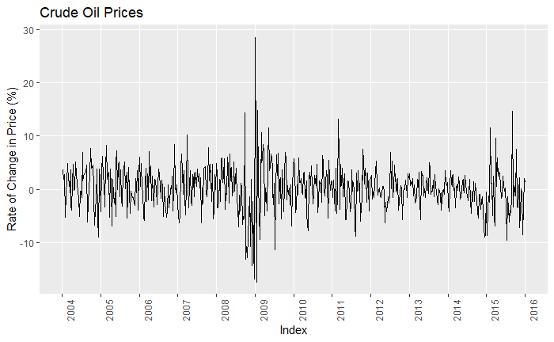

```r
#Plotting the rate of change in spot price
autoplot(rate) + labs(title="Crude Oil Prices", y="Rate of Change in Price (%)") + scale_x_date(date_breaks = "1 year", date_minor_breaks = "1 year", date_labels = "%Y") + theme(axis.text.x = element_text(angle = 90, vjust=1.5), panel.grid.minor = element_blank())
```

## c)

Analyze the distribution of rate using a histogram and a normal quantile plot. Is the distribution of rate symmetric? Is it close to a normal distribution?

# Answer:

In much the same way as we can see in the graphed rate of change, the majority of the rate from week to week is between +5% and -5% and it does appear to be almost symmetrical, with a bit more on the falling on the + side. This is close to a normal distribution, as seen in the quantile plot.

```r
library(fBasics)

# COMPUTE SUMMARY STATISTICS
basicStats(rate)
```

|  | x |
| --- | --- |
| nobs | 626.000000 |
| NAs | 0.000000 |
| Minimum | -17.386415 |
| Maximum | 28.562765 |
| 1. Quartile | -2.213756 |
| 3. Quartile | 2.565308 |
| Mean | 0.107121 |
| Median | 0.175455 |
| Sum | 67.057942 |
| SE Mean | 0.167251 |

[output cut: 6 more lines]

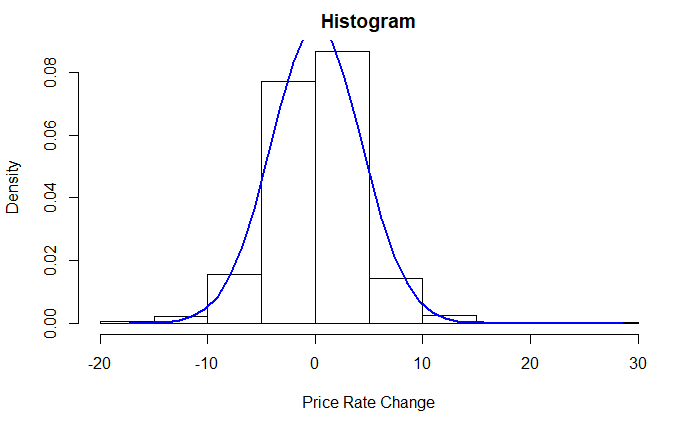

```r
# Creating a histogram of the rate of change in price
hist(rate, xlab="Price Rate Change", prob=TRUE, main="Histogram")
# add approximating normal density curve
xfit<-seq(min(rate),max(rate),length=40)
yfit<-dnorm(xfit,mean=mean(rate),sd=sd(rate))
lines(xfit, yfit, col="blue", lwd=2)
```

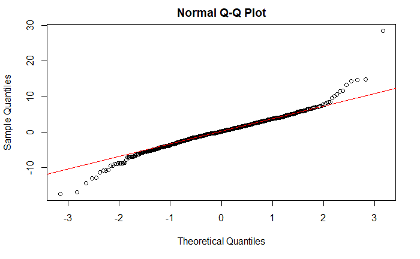

```r
#creating the Q-Q plot of the rate of change
qqnorm(rate)
qqline(rate, col = 2)
```

## d)

Create and plot the log value of the spot price. Reflect on your findings.

# Answer:

Again, we see that the largest variation takes place when the price of crude oil crashes.

```r
#Defining the log value of the spot price
crudelog = diff(log(crudets))
summary(crudelog)
```

```
     Index               crudelog
 Min.   :2004-01-09   Min.   :-0.1909961
 1st Qu.:2007-01-06   1st Qu.:-0.0223863
 Median :2010-01-04   Median : 0.0017530
 Mean   :2010-01-04   Mean   : 0.0001992
 3rd Qu.:2013-01-02   3rd Qu.: 0.0253295
 Max.   :2016-01-01   Max.   : 0.2512471
```

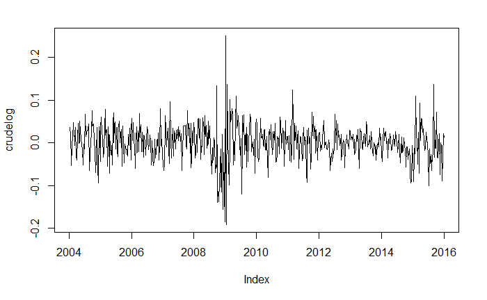

```r
#plotting the log of the spot price
plot(crudelog)
```

# Problem 2:

Hyndman, Chapter 2, problem 3 (uses the ts object)

Download some monthly Australian retail data from the book website. These represent retail sales in various categories for different Australian states, and are stored in a MS-Excel file.

You can read the data into R with the following script:

```r
work_dir <- "D:/Google Drive/Corey - School/!Fall 2018 B/BIA 6315 - Time Series and Forecasting/Assignment 1"
setwd(work_dir)
retaildata <- readxl::read_excel("retail.xlsx", skip=1)
```

The second argument (skip=1) is required because the Excel sheet has two header rows. Select one of the time series as follows (but replace the column name with your own chosen column):

```r
myts <- ts(retaildata[,"A3349575C"],
  frequency=12, start=c(1982,4))
```

Explore your chosen retail time series using the following functions:

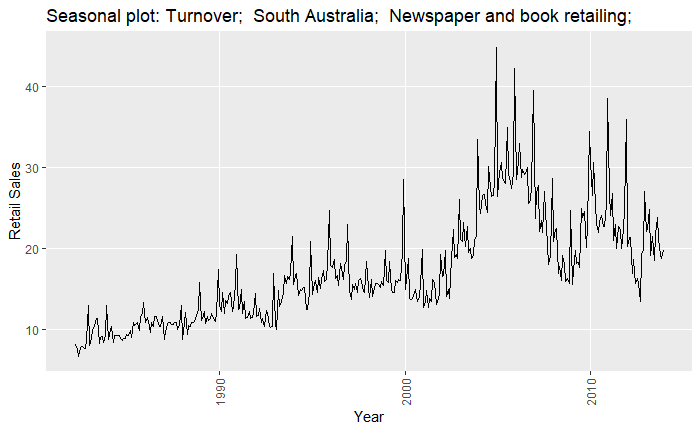

```r
library(ggfortify)
autoplot(myts) + labs(title="Seasonal plot: Turnover;  South Australia;  Newspaper and book retailing;",x="Year", y="Retail Sales") + theme(axis.text.x = element_text(angle = 90, vjust=0.5), panel.grid.minor = element_blank())
```

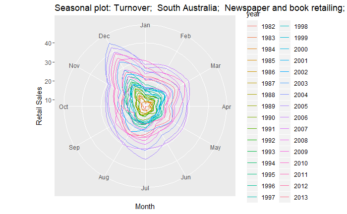

```r
library(forecast)
ggseasonplot(myts, polar=TRUE) +
ylab("Retail Sales") +
ggtitle("Seasonal plot: Turnover;  South Australia;  Newspaper and book retailing;")
```

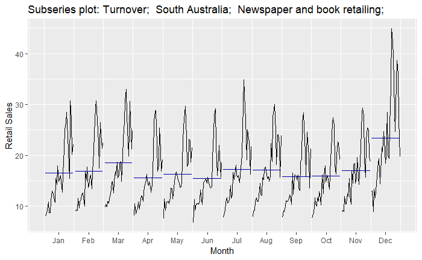

```r
ggsubseriesplot(myts) + ylab("Retail Sales") +
ggtitle("Subseries plot: Turnover;  South Australia;  Newspaper and book retailing;")
```

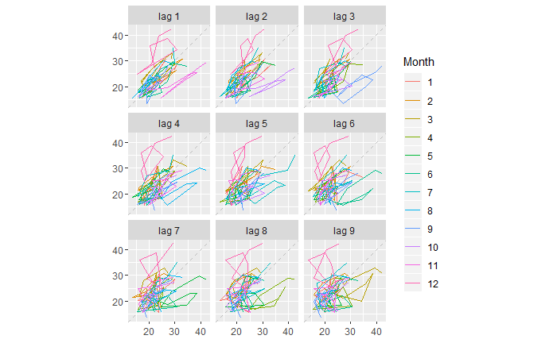

```r
myts2005 <- window(myts, start=2005)
gglagplot(myts2005, lags = 9)
```

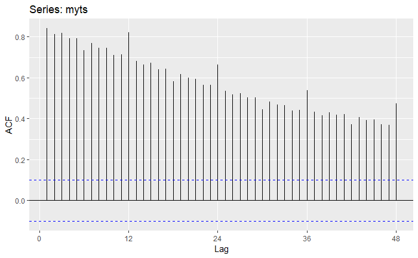

```r
ggAcf(myts, lag = 48)
```

# Can you spot any seasonality, cyclicity and trend? What do you learn about the series?

# Problem 3:

Using the Lubridate package, complete the tutorial questions at this link. See week 1- lubridate example code.

https://www.r-bloggers.com/dates-and-times-simple-and-easy-with-lubridate-exercises-part-1/

The ymd() series of functions are used to parse character strings into dates. The letters y, m, and d correspond to the year, month, and day elements of a date-time.

## Exercise 1

Populate a variable called “start_date” with a date representation of string “23012017”

```r
library(lubridate)
start_date <- dmy(23012017)
start_date
```

[output not shown]

## Exercise 2

Use the lubridate function today to print the current date

```r
today()
```

[output not shown]

## Exercise 3

Extract the year part from the “start_date” variable created on exercise 1

```r
year(start_date)
```

[output not shown]

## Exercise 4

Extract the month part from the “start_date” variable created on exercise 1

```r
month(start_date)
```

[output not shown]

## Exercise 5

Extract the day part from the “start_date” variable created on exercise 1

```r
day(start_date)
```

[output not shown]

## Exercise 6

Set the month in variable “start_date” to February

```r
start_date <- update(start_date,month=2)
start_date
```

[output not shown]

## Exercise 7

Add 6 days to variable “start_date”. Did you notice what happened to the month value?

```r
start_date <- start_date + days(6)
start_date
```

[output not shown]

## Exercise 8

Substract 3 months from variable “start_date”

```r
start_date <- start_date - months(3)
start_date
```

[output not shown]

## Exercise 9 (Advanced)

Populate a field called concatenated_dates with a vector of dates containing the following values: “31.12.2015”, “01.01.2016”, “15.02.2016”

```r
concatenated_dates <- dmy(c("31.12.2015", "01.01.2016",  "15.02.2016"))
concatenated_dates
```

[output not shown]

# Exercise 10 (Advanced)

Calculate in a short and simple way the addition of 1 thru 10 days to “start_date” variable

```r
start_date + c(1:10) * days(1)
```

[output not shown]